# GDP per Capita and Male Life Expectancy Analysis (2020)

## GDP per Capita in 2020

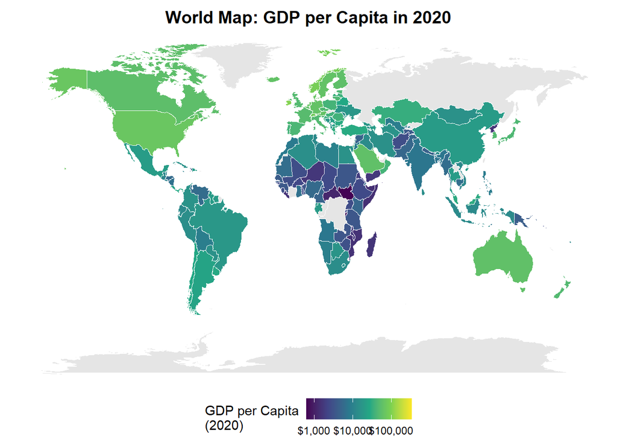

The world map above shows GDP per capita across countries in 2020. Countries with higher GDP per capita are shown in brighter colors, while countries with missing data appear in grey.

## Male Life Expectancy in 2020

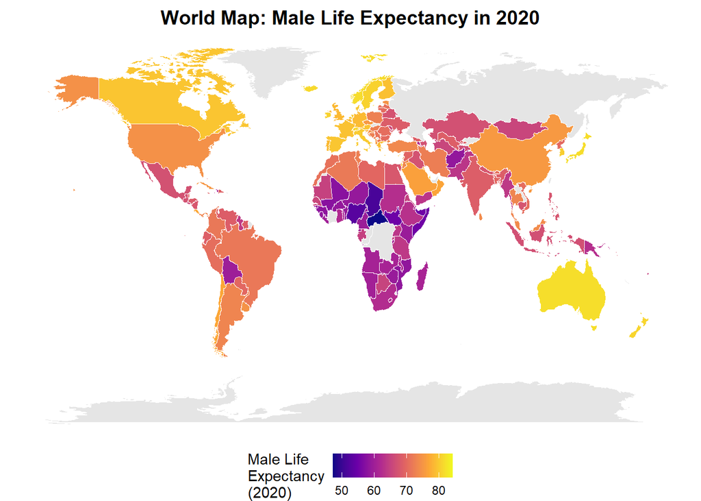

The world map above displays male life expectancy across countries in 2020. Countries with higher life expectancy are shown in brighter colors.

## Relationship Between GDP per Capita and Male Life Expectancy (2020)

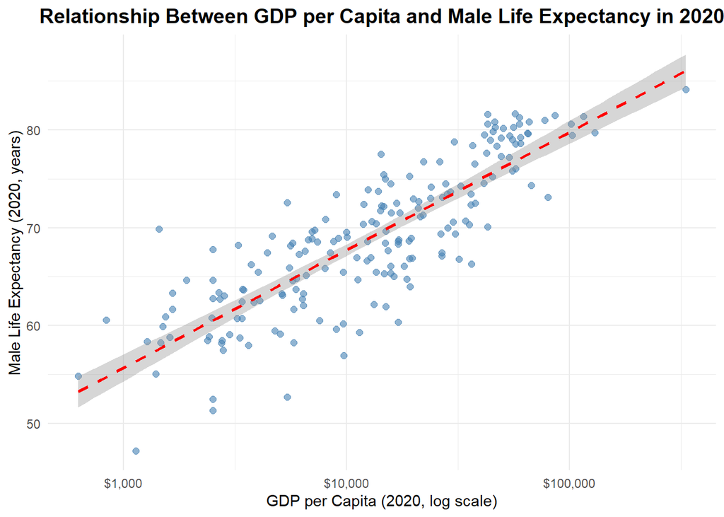

### Summary Statistics

Summary Statistics for GDP per Capita and Male Life Expectancy (2020)

| Number of Countries | Mean GDP per Capita | Median GDP per Capita | Mean Life Expectancy | Median Life Expectancy | Correlation |
| --- | --- | --- | --- | --- | --- |
| 193 | 23690.5 | 14397.15 | 68.95 | 68.76 | 0.64 |

## Interpretation

The scatterplot and correlation analysis reveal a **positive relationship** between GDP per capita and male life expectancy in 2020. This relationship shows that:

1. **Strong Positive Correlation**: Countries with higher GDP per capita tend to have higher male life expectancy. The correlation coefficient is approximately 0.64.
2. **Diminishing Returns**: The relationship appears to follow a logarithmic pattern, suggesting that increases in GDP per capita have a stronger impact on life expectancy at lower income levels. Once countries reach a certain level of economic development, further increases in GDP per capita result in smaller gains in life expectancy.
3. **Global Health Disparities**: The wide spread of data points indicates significant global health and economic disparities. Some countries achieve relatively high life expectancy despite lower GDP per capita (possibly due to effective public health systems), while others with high GDP may not achieve proportionally high life expectancy.
4. **Policy Implications**: This relationship suggests that economic development is an important factor in improving health outcomes, but it is not the sole determinant. Other factors such as healthcare infrastructure, education, and public health policies also play crucial roles.

## Reflection

I tried using Juluis and then now Cursor… I think Cursor is good for my needs. I was straightforward in creating the Rmarkdown and since i understand R it was easy for me to make iterations. For example it did not get the actual column name for 2020 data. I had to do that manually. But alot of the code writing was done by Cursor and it was pretty straightforward.